# Auto gating update

April 11th, 2017

### OpenCyto

[Finak, Frelinger, Jiang, et al. (2014)](https://doi.org/10.1371%2Fjournal.pcbi.1003806)

- Mimics manual gating by focusing on 2 channels at a time
  - can follow traditional gate hierarchy
  - e.g. gate lymph, then single, then live, etc
- Pipeline templates defined in .csv file
  - defines algorithmic approach for each gate to be applied across many samples
  - not “just push go”, takes some setup for a decent template
- Results are interpretable and labelled populations
  - not geared toward detecting novel cell types

### OpenCyto

> The two top performing gating algorithms - OpenCyto (v. 1.7.4), flowDensity (v. 1.4.0) - in a study run by the FlowCAP consortium aimed at selecting the best performing algorithms for this larger study were chosen for the analysis presented in this paper. *Standardizing Flow Cytometry Immunophenotyping Analysis from the Human ImmunoPhenotyping Consortium* [Finak, Langweiler, Jaimes, et al. (2016)](https://doi.org/10.1038%2Fsrep20686)
- Stole template from above as a start
  - our panel 1 template currently lives [here](https://github.com/PankratzLab/auto-fcs/blob/master/explore/openCyto/lymph.dev.b.csv)

### Current progress overview

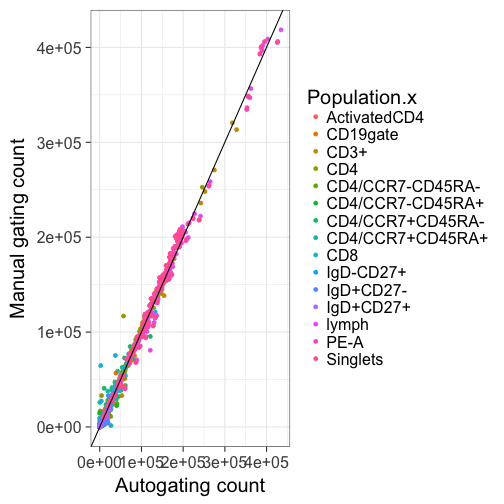

| N_SAMPS | N_DATA | RHO | BETA | BETA_SE | R2 | ICC_1 |
| --- | --- | --- | --- | --- | --- | --- |
| 151 | 2265 | 0.9846 | 1.015 | 0.0015 | 0.9949 | 0.9972 |

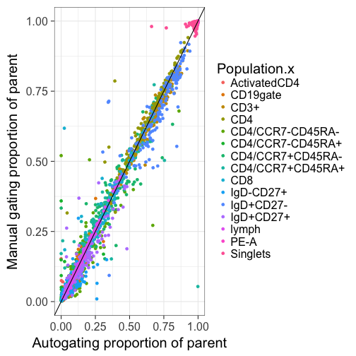

| N_SAMPS | N_DATA | RHO | BETA | BETA_SE | R2 | ICC_1 |
| --- | --- | --- | --- | --- | --- | --- |
| 151 | 2265 | 0.979 | 0.9861 | 0.0031 | 0.9782 | 0.989 |

### Example OpenCyto gates

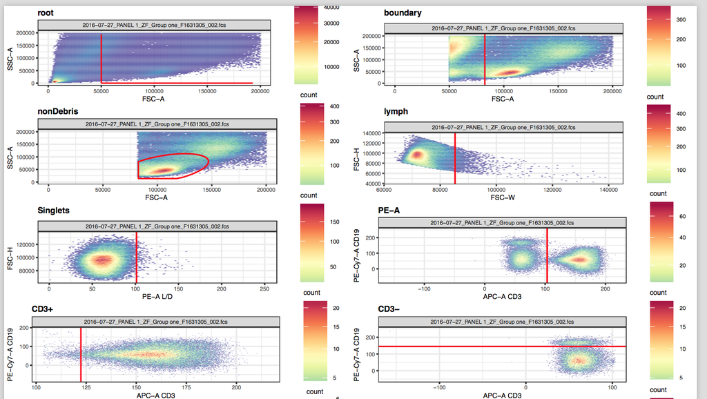

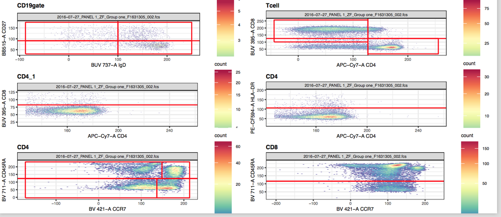

### Next few slides

- For each gate
  - a good-ish example of an auto gate
  - a bad example/common problems
  - overview of gate performance

### Lymphocytes (SSC-A v FSC-A)

[figure not shown]

|  | FN | TN | TP | FP | ACC | SENS | SPEC | PREC |
| --- | --- | --- | --- | --- | --- | --- | --- | --- |
| Freq | 1490 | 142572 | 28420 | 0 | 0.9914 | 0.9502 | 1 | 1 |

[figure not shown]

|  | FN | FP | TN | TP | ACC | SENS | SPEC | PREC |
| --- | --- | --- | --- | --- | --- | --- | --- | --- |
| Freq | 2849 | 22579 | 778949 | 38211 | 0.9698 | 0.9306 | 0.9718 | 0.6286 |

- may decrease the quantile of lymph cluster from 95% back to 90%

### Lymphocytes (SSC-A v FSC-A)

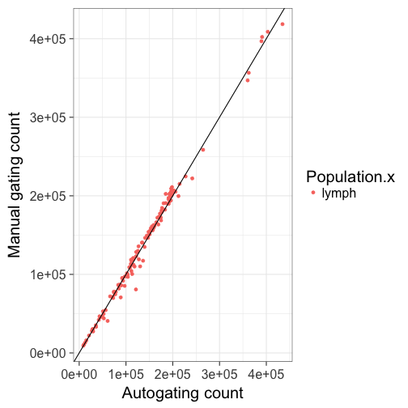

| N_SAMPS | N_DATA | RHO | BETA | BETA_SE | R2 | ICC_1 |
| --- | --- | --- | --- | --- | --- | --- |
| 151 | 151 | 0.9885 | 1.014 | 0.0078 | 0.9912 | 0.9953 |

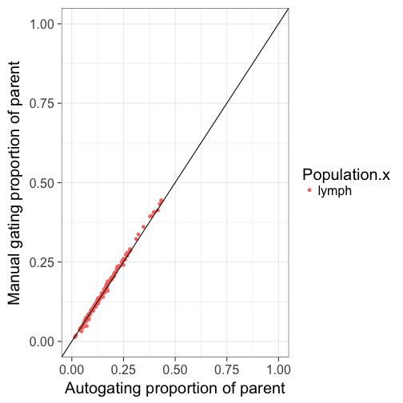

| N_SAMPS | N_DATA | RHO | BETA | BETA_SE | R2 | ICC_1 |
| --- | --- | --- | --- | --- | --- | --- |
| 151 | 151 | 0.9968 | 1.038 | 0.005 | 0.9966 | 0.9972 |

### Single Cells (FSC-H v FSC-W)

[figure not shown]

|  | FN | FP | TN | TP | ACC | SENS | SPEC | PREC |
| --- | --- | --- | --- | --- | --- | --- | --- | --- |
| Freq | 224 | 10743 | 1096246 | 84062 | 0.9908 | 0.9973 | 0.9903 | 0.8867 |

[figure not shown]

|  | FN | FP | TN | TP | ACC | SENS | SPEC | PREC |
| --- | --- | --- | --- | --- | --- | --- | --- | --- |
| Freq | 10397 | 46 | 1237576 | 143142 | 0.9925 | 0.9323 | 1 | 0.9997 |

- Force FSC-W+ to have a minimum cutoff or make more inclusive ? What is the manual strategy?

### Single Cells (FSC-H v FSC-W)

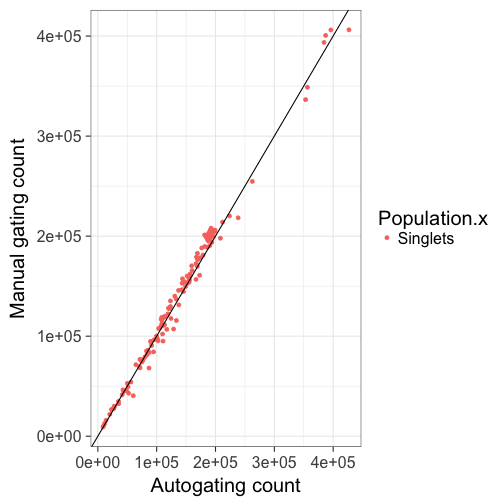

| N_SAMPS | N_DATA | RHO | BETA | BETA_SE | R2 | ICC_1 |
| --- | --- | --- | --- | --- | --- | --- |
| 151 | 151 | 0.9822 | 1.018 | 0.0087 | 0.9892 | 0.9935 |

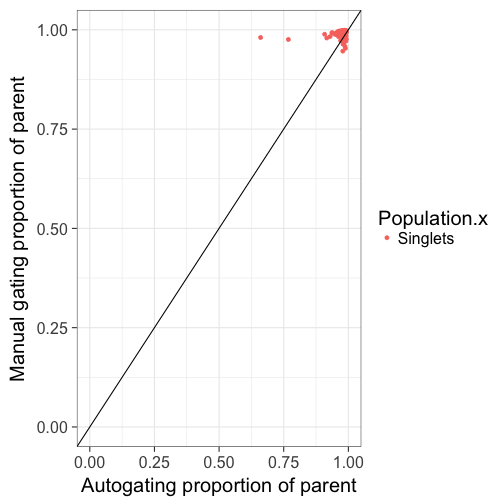

| N_SAMPS | N_DATA | RHO | BETA | BETA_SE | R2 | ICC_1 |
| --- | --- | --- | --- | --- | --- | --- |
| 151 | 151 | 0.0585 | 0.032 | 0.0225 | 0.0134 | -0.0278 |

### Live cells (PE-)

[figure not shown]

|  | FN | FP | TN | TP | ACC | SENS | SPEC | PREC |
| --- | --- | --- | --- | --- | --- | --- | --- | --- |
| Freq | 213 | 10668 | 1096940 | 83454 | 0.9909 | 0.9975 | 0.9904 | 0.8867 |

[figure not shown]

|  | FN | FP | TN | TP | ACC | SENS | SPEC | PREC |
| --- | --- | --- | --- | --- | --- | --- | --- | --- |
| Freq | 17050 | 7378 | 476522 | 178534 | 0.964 | 0.9128 | 0.9848 | 0.9603 |

- victim of singlet gate

### Live cells (PE-)

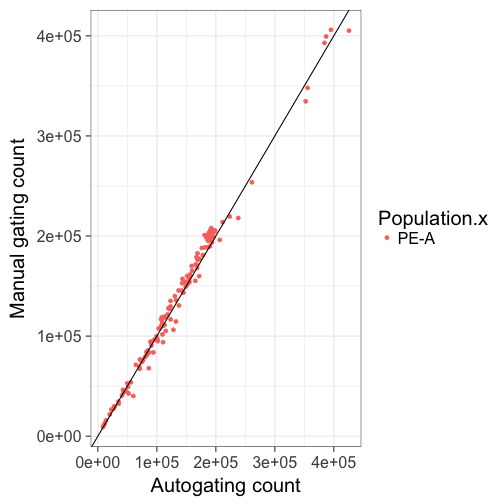

| N_SAMPS | N_DATA | RHO | BETA | BETA_SE | R2 | ICC_1 |
| --- | --- | --- | --- | --- | --- | --- |
| 151 | 151 | 0.9821 | 1.019 | 0.0088 | 0.9889 | 0.9933 |

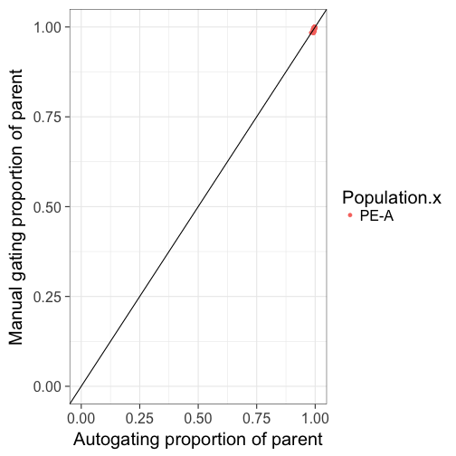

| N_SAMPS | N_DATA | RHO | BETA | BETA_SE | R2 | ICC_1 |
| --- | --- | --- | --- | --- | --- | --- |
| 151 | 151 | 0.6801 | 1.064 | 0.0931 | 0.4672 | 0.6227 |

### Tcells (CD3+ CD19-)

[figure not shown]

|  | FN | FP | TN | TP | ACC | SENS | SPEC | PREC |
| --- | --- | --- | --- | --- | --- | --- | --- | --- |
| Freq | 4244 | 273 | 1454088 | 136130 | 0.9972 | 0.9698 | 0.9998 | 0.998 |

[figure not shown]

|  | FN | FP | TN | TP | ACC | SENS | SPEC | PREC |
| --- | --- | --- | --- | --- | --- | --- | --- | --- |
| Freq | 1393 | 3028 | 603276 | 43658 | 0.9932 | 0.9691 | 0.995 | 0.9351 |

- can trim sides (and a bit less on left side)

### Tcells (CD3+ CD19-)

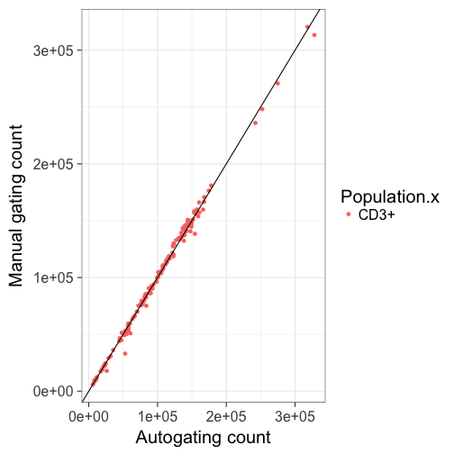

| N_SAMPS | N_DATA | RHO | BETA | BETA_SE | R2 | ICC_1 |
| --- | --- | --- | --- | --- | --- | --- |
| 151 | 151 | 0.9958 | 0.9979 | 0.0054 | 0.9956 | 0.9978 |

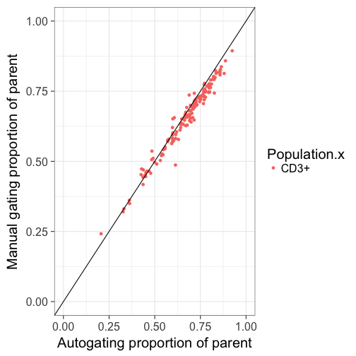

| N_SAMPS | N_DATA | RHO | BETA | BETA_SE | R2 | ICC_1 |
| --- | --- | --- | --- | --- | --- | --- |
| 151 | 151 | 0.9784 | 0.9059 | 0.0133 | 0.9687 | 0.9711 |

### Helper Tcells-CD4+

[figure not shown]

|  | FN | FP | TN | TP | ACC | SENS | SPEC | PREC |
| --- | --- | --- | --- | --- | --- | --- | --- | --- |
| Freq | 880 | 104 | 524259 | 6874 | 0.9982 | 0.8865 | 0.9998 | 0.9851 |

[figure not shown]

|  | FN | FP | TN | TP | ACC | SENS | SPEC | PREC |
| --- | --- | --- | --- | --- | --- | --- | --- | --- |
| Freq | 5807 | 7577 | 963616 | 94294 | 0.9875 | 0.942 | 0.9922 | 0.9256 |

### Helper Tcells-CD4+

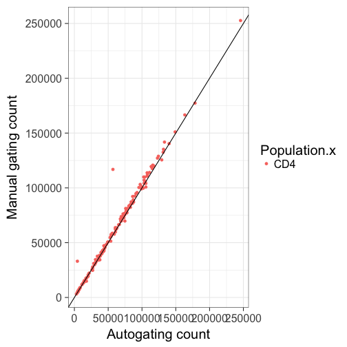

| N_SAMPS | N_DATA | RHO | BETA | BETA_SE | R2 | ICC_1 |
| --- | --- | --- | --- | --- | --- | --- |
| 151 | 151 | 0.9891 | 1.015 | 0.0113 | 0.982 | 0.9897 |

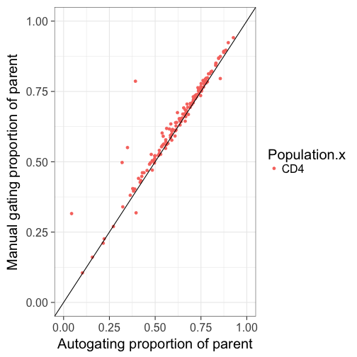

| N_SAMPS | N_DATA | RHO | BETA | BETA_SE | R2 | ICC_1 |
| --- | --- | --- | --- | --- | --- | --- |
| 151 | 151 | 0.9709 | 0.9173 | 0.0215 | 0.9241 | 0.9539 |

### central memory helper Tcells (CCR7+ CD45RA-)

[figure not shown]

### central memory helper Tcells (CCR7+ CD45RA-)

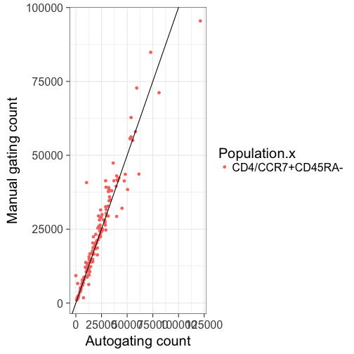

| N_SAMPS | N_DATA | RHO | BETA | BETA_SE | R2 | ICC_1 |
| --- | --- | --- | --- | --- | --- | --- |
| 151 | 151 | 0.9643 | 0.9344 | 0.0238 | 0.9121 | 0.9542 |

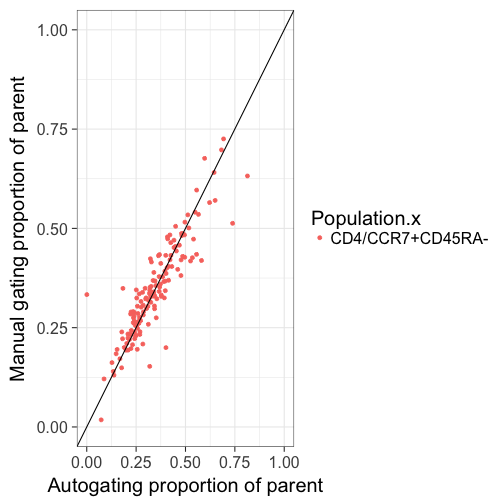

| N_SAMPS | N_DATA | RHO | BETA | BETA_SE | R2 | ICC_1 |
| --- | --- | --- | --- | --- | --- | --- |
| 151 | 151 | 0.898 | 0.7929 | 0.0329 | 0.7959 | 0.8867 |

### effector helper Tcells (CCR7- CD45RA+)

[figure not shown]

|  | FN | FP | TN | TP | ACC | SENS | SPEC | PREC |
| --- | --- | --- | --- | --- | --- | --- | --- | --- |
| Freq | 3307 | 1114 | 2113444 | 22741 | 0.9979 | 0.873 | 0.9995 | 0.9533 |

[figure not shown]

|  | FN | FP | TN | TP | ACC | SENS | SPEC | PREC |
| --- | --- | --- | --- | --- | --- | --- | --- | --- |
| Freq | 953 | 19155 | 786225 | 21460 | 0.9757 | 0.9575 | 0.9762 | 0.5284 |

### effector helper Tcells (CCR7- CD45RA+)

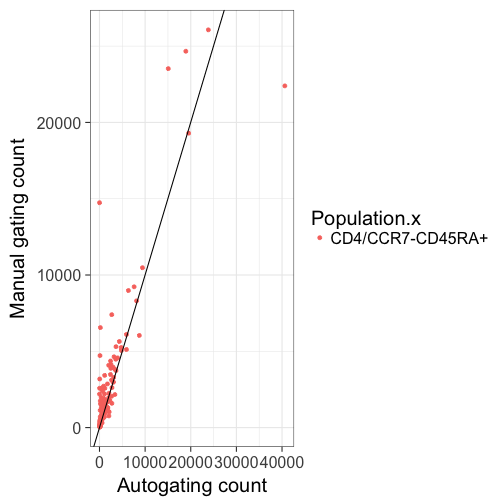

| N_SAMPS | N_DATA | RHO | BETA | BETA_SE | R2 | ICC_1 |
| --- | --- | --- | --- | --- | --- | --- |
| 151 | 151 | 0.7592 | 0.8319 | 0.0386 | 0.7567 | 0.8635 |

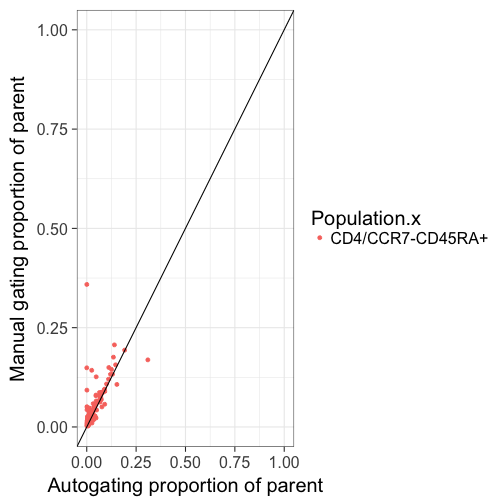

| N_SAMPS | N_DATA | RHO | BETA | BETA_SE | R2 | ICC_1 |
| --- | --- | --- | --- | --- | --- | --- |
| 151 | 151 | 0.7198 | 0.7991 | 0.0695 | 0.47 | 0.661 |

### effector memory helper Tcells (CCR7- CD45RA-)

[figure not shown]

|  | FN | FP | TN | TP | ACC | SENS | SPEC | PREC |
| --- | --- | --- | --- | --- | --- | --- | --- | --- |
| Freq | 1509 | 240 | 1382591 | 6821 | 0.9987 | 0.8188 | 0.9998 | 0.966 |

[figure not shown]

|  | FN | FP | TN | TP | ACC | SENS | SPEC | PREC |
| --- | --- | --- | --- | --- | --- | --- | --- | --- |
| Freq | 974 | 6718 | 948445 | 12272 | 0.9921 | 0.9265 | 0.993 | 0.6462 |

### effector memory helper Tcells (CCR7- CD45RA-)

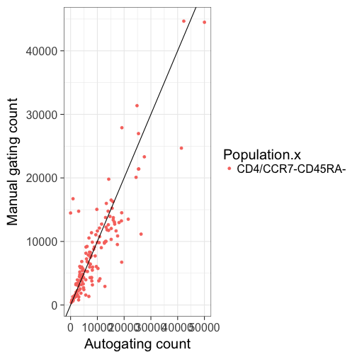

| N_SAMPS | N_DATA | RHO | BETA | BETA_SE | R2 | ICC_1 |
| --- | --- | --- | --- | --- | --- | --- |
| 151 | 151 | 0.8323 | 0.7918 | 0.0357 | 0.7677 | 0.8681 |

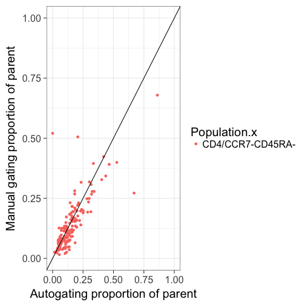

| N_SAMPS | N_DATA | RHO | BETA | BETA_SE | R2 | ICC_1 |
| --- | --- | --- | --- | --- | --- | --- |
| 151 | 151 | 0.7935 | 0.7057 | 0.0462 | 0.6104 | 0.7736 |

### naive helper Tcells (CCR7+ CD45RA+)

[figure not shown]

|  | FN | FP | TN | TP | ACC | SENS | SPEC | PREC |
| --- | --- | --- | --- | --- | --- | --- | --- | --- |
| Freq | 827 | 244 | 926060 | 26892 | 0.9989 | 0.9702 | 0.9997 | 0.991 |

[figure not shown]

|  | FN | FP | TN | TP | ACC | SENS | SPEC | PREC |
| --- | --- | --- | --- | --- | --- | --- | --- | --- |
| Freq | 18678 | 251 | 789709 | 19155 | 0.9771 | 0.5063 | 0.9997 | 0.9871 |

### naive helper Tcells (CCR7+ CD45RA+)

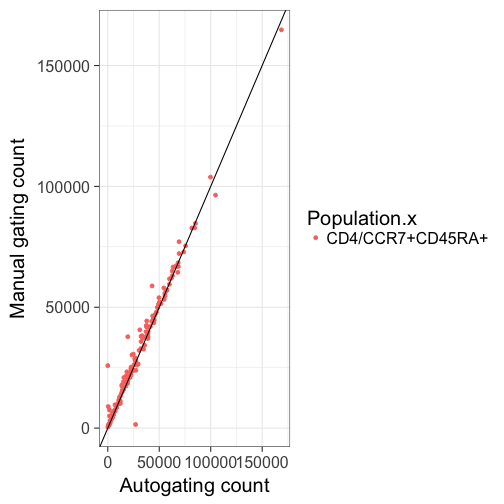

| N_SAMPS | N_DATA | RHO | BETA | BETA_SE | R2 | ICC_1 |
| --- | --- | --- | --- | --- | --- | --- |
| 151 | 151 | 0.9714 | 0.9777 | 0.0133 | 0.9733 | 0.9853 |

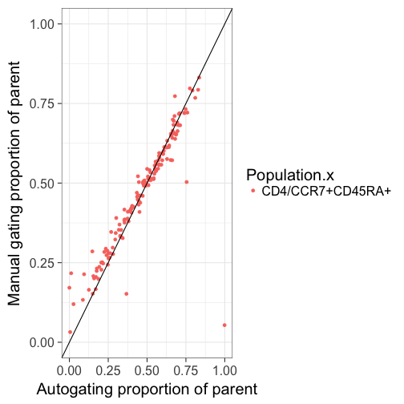

| N_SAMPS | N_DATA | RHO | BETA | BETA_SE | R2 | ICC_1 |
| --- | --- | --- | --- | --- | --- | --- |
| 151 | 151 | 0.9394 | 0.7853 | 0.0327 | 0.7947 | 0.885 |

### cytotoxic Tcells-CD8+

[figure not shown]

|  | FN | FP | TN | TP | ACC | SENS | SPEC | PREC |
| --- | --- | --- | --- | --- | --- | --- | --- | --- |
| Freq | 2478 | 2311 | 1665944 | 30763 | 0.9972 | 0.9255 | 0.9986 | 0.9301 |

[figure not shown]

|  | FN | FP | TN | TP | ACC | SENS | SPEC | PREC |
| --- | --- | --- | --- | --- | --- | --- | --- | --- |
| Freq | 2892 | 5308 | 926823 | 33386 | 0.9915 | 0.9203 | 0.9943 | 0.8628 |

### cytotoxic Tcells-CD8+

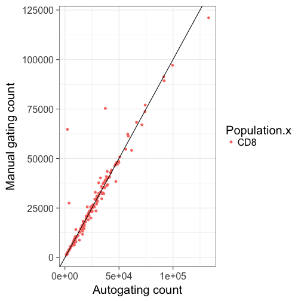

| N_SAMPS | N_DATA | RHO | BETA | BETA_SE | R2 | ICC_1 |
| --- | --- | --- | --- | --- | --- | --- |
| 151 | 151 | 0.9485 | 0.9527 | 0.0259 | 0.9011 | 0.9493 |

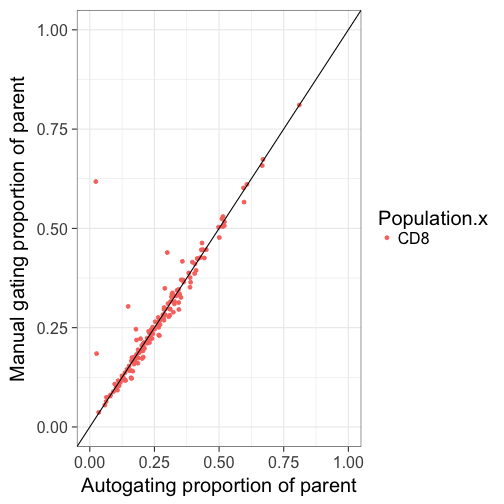

| N_SAMPS | N_DATA | RHO | BETA | BETA_SE | R2 | ICC_1 |
| --- | --- | --- | --- | --- | --- | --- |
| 151 | 151 | 0.9343 | 0.9315 | 0.0324 | 0.847 | 0.9204 |

### B cells (CD3- CD19+)

[figure not shown]

|  | FN | FP | TN | TP | ACC | SENS | SPEC | PREC |
| --- | --- | --- | --- | --- | --- | --- | --- | --- |
| Freq | 531 | 895 | 937430 | 15167 | 0.9985 | 0.9662 | 0.999 | 0.9443 |

[figure not shown]

|  | FN | FP | TN | TP | ACC | SENS | SPEC | PREC |
| --- | --- | --- | --- | --- | --- | --- | --- | --- |
| Freq | 521 | 8506 | 2738594 | 23528 | 0.9967 | 0.9783 | 0.9969 | 0.7345 |

- typically over- or under-calling the sneaky Bcells on CD19 dimension

### B cells (CD3- CD19+)

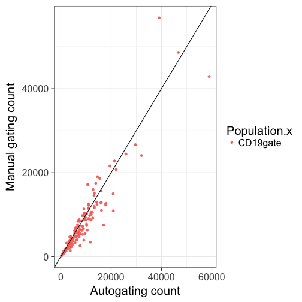

| N_SAMPS | N_DATA | RHO | BETA | BETA_SE | R2 | ICC_1 |
| --- | --- | --- | --- | --- | --- | --- |
| 151 | 151 | 0.9377 | 0.9254 | 0.0296 | 0.8679 | 0.9262 |

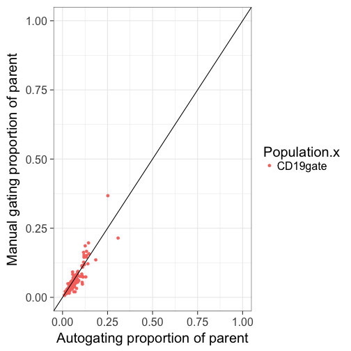

| N_SAMPS | N_DATA | RHO | BETA | BETA_SE | R2 | ICC_1 |
| --- | --- | --- | --- | --- | --- | --- |
| 151 | 151 | 0.8809 | 1.002 | 0.0428 | 0.7857 | 0.8714 |

### naive Bcells (CD27- IgD+)

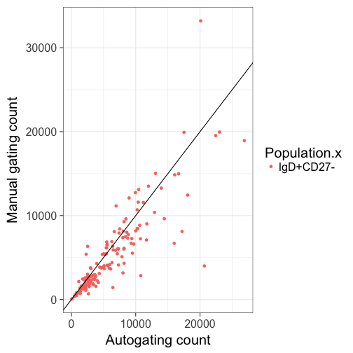

| N_SAMPS | N_DATA | RHO | BETA | BETA_SE | R2 | ICC_1 |
| --- | --- | --- | --- | --- | --- | --- |
| 151 | 151 | 0.909 | 0.8173 | 0.0403 | 0.7344 | 0.8424 |

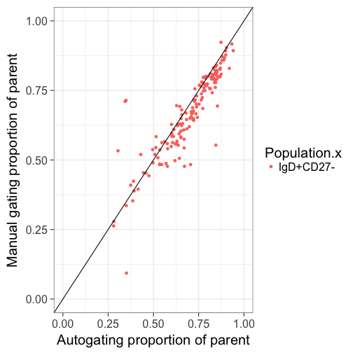

| N_SAMPS | N_DATA | RHO | BETA | BETA_SE | R2 | ICC_1 |
| --- | --- | --- | --- | --- | --- | --- |
| 151 | 151 | 0.9128 | 0.8498 | 0.0367 | 0.7828 | 0.868 |

### IgD- memory Bcells (CD27+)

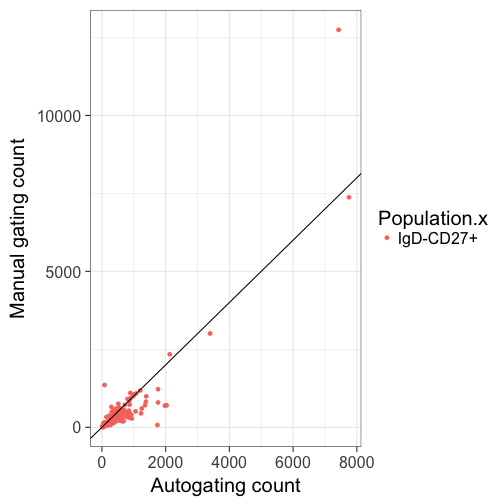

| N_SAMPS | N_DATA | RHO | BETA | BETA_SE | R2 | ICC_1 |
| --- | --- | --- | --- | --- | --- | --- |
| 151 | 151 | 0.823 | 1.16 | 0.0443 | 0.8211 | 0.8764 |

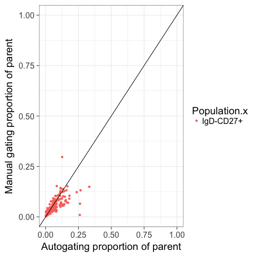

| N_SAMPS | N_DATA | RHO | BETA | BETA_SE | R2 | ICC_1 |
| --- | --- | --- | --- | --- | --- | --- |
| 151 | 151 | 0.8057 | 0.4608 | 0.0449 | 0.4145 | 0.5765 |

### IgD+ memory Bcells (CD27+)

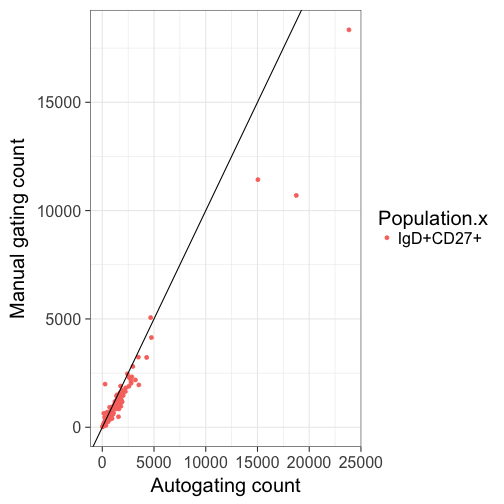

| N_SAMPS | N_DATA | RHO | BETA | BETA_SE | R2 | ICC_1 |
| --- | --- | --- | --- | --- | --- | --- |
| 151 | 151 | 0.9212 | 0.7128 | 0.0113 | 0.964 | 0.925 |

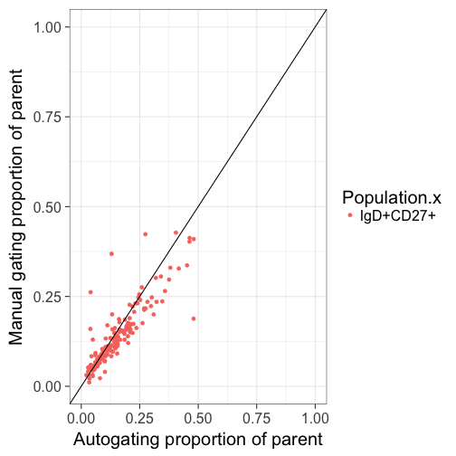

| N_SAMPS | N_DATA | RHO | BETA | BETA_SE | R2 | ICC_1 |
| --- | --- | --- | --- | --- | --- | --- |
| 151 | 151 | 0.8844 | 0.7361 | 0.0349 | 0.7487 | 0.8423 |

### Summary

- OpenCyto seems to work
- Lots of room for improvement
- Iterative process

### ICC

From [Wikipedia](https://en.wikipedia.org/wiki/Intraclass_correlation)

[Cicchetti (1994)](https://doi.org/10.1037%2F1040-3590.6.4.284) gives the following often quoted guidelines for interpretation for kappa or ICC inter-rater agreement measures:

- Less than 0.40—poor.
- Between 0.40 and 0.59—Fair.
- Between 0.60 and 0.74—Good.
- Between 0.75 and 1.00—Excellent.